# What Predicts Repayment Difficulty?

Home Credit application data · [Kaggle competition](https://www.kaggle.com/competitions/home-credit-default-risk)

Evan Reynolds

## The Short Version

8.07%repayment difficulty across all applications

Raw loan amount shows no clear pattern on its own.

Driver performance is compared with the 8.07% portfolio default rate.

## Dataset Overview

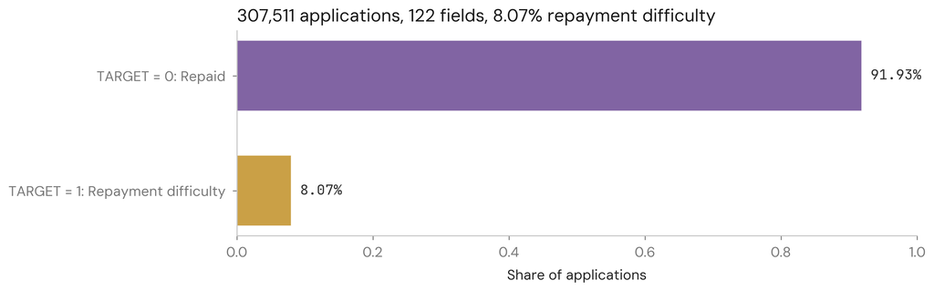

**Class imbalance:** repayment difficulty affects 8.07% of applications, about 11 repaid applications for every one with difficulty. Each group is therefore read against the 8.07% line.

## How to Read the Charts

Applicants are sorted into bins from low to high value for each field. Each bin’s repayment-difficulty rate is compared with the **8.07% portfolio rate**.

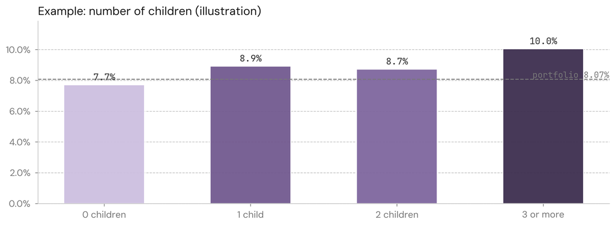

Lighter bars have lower repayment-difficulty rates and darker bars have higher rates. Colour scale: **Lower Repayment Difficulty → Higher Repayment Difficulty.**

- **Clear separation:** default rates vary across groups.
- **Little separation:** default rates stay close to the portfolio average.

## External Credit Scores

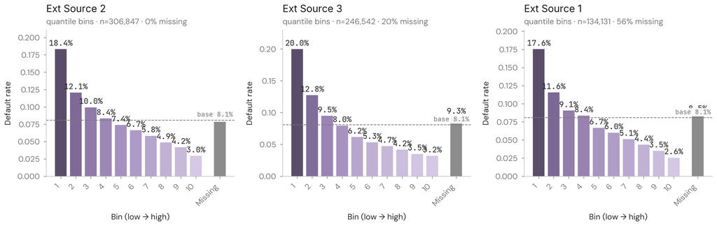

**External credit scores show the strongest separation in default rates among the screened variables.**

## Age and Job Tenure

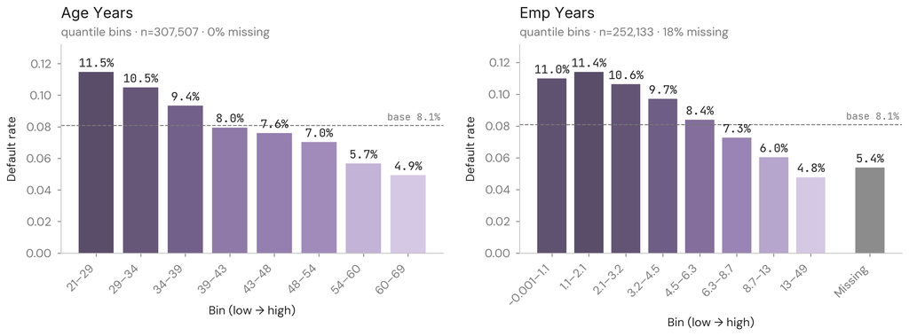

**Default rates are higher among younger applicants and those with shorter job tenure.** The missing job-tenure bin is pensioners, whose rate is low.

## Education

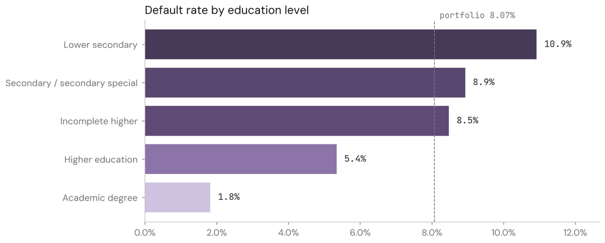

Default rates rise as education level falls, from **1.8%** for academic degree to **10.9%** for lower secondary.

## Loan Amount

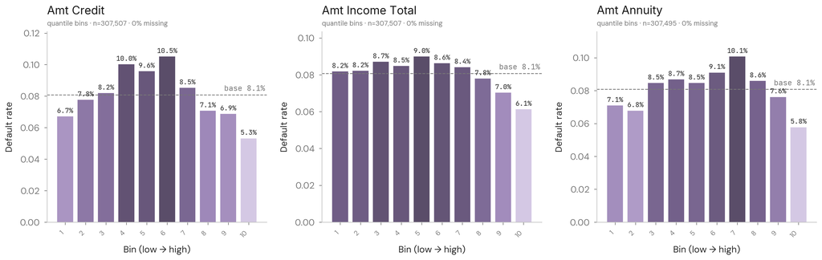

**Default rate does not show a clear monotonic relationship with loan amount.**

## Affordability Ratios

Engineered ratios: **Credit-to-Goods Ratio (LVR)** is loan amount divided by goods price, **Employed-to-Age Ratio** is job tenure divided by age, and **Debt-to-Income Ratio** is annuity divided by income.

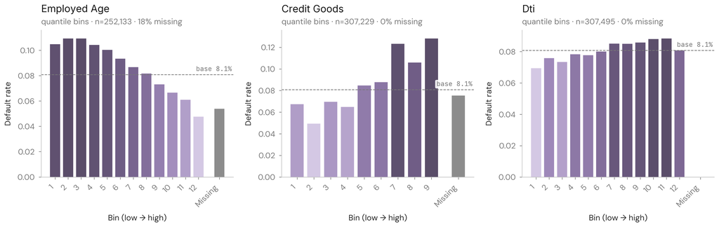

**The Employed-to-Age and Credit-to-Goods (LVR) ratios show separation across groups. Debt-to-income does not show a clear pattern.**

## WOE and Information Value

| Feature | Information Value | Decision |
| --- | --- | --- |
| External Credit Score 3 | 0.334 | Retained |
| External Credit Score 2 | 0.320 | Retained |
| External Credit Score 1 | 0.149 | Retained |
| Job Tenure | 0.116 | Retained |
| Annuity-to-Credit Ratio | 0.112 | Retained |
| Employed-to-Age Ratio | 0.092 | Retained |
| Goods Price | 0.091 | Retained |
| DAYS_BIRTH | 0.091 | Retained |
| Occupation | 0.079 | Retained |
| Credit-to-Goods Ratio (LVR) | 0.074 | Retained |
| Organisation Band | 0.072 | Retained |
| Loan Amount | 0.059 | Retained |
| Income Type | 0.057 | Retained |
| Regional Rating | 0.052 | Retained |
| Education | 0.048 | Retained |
| REGION_RATING_CLIENT | 0.048 | Retained |
| DAYS_LAST_PHONE_CHANGE | 0.045 | Retained |
| DAYS_ID_PUBLISH | 0.038 | Retained |
| FLOORSMAX_AVG | 0.037 | Retained |
| TOTALAREA_MODE | 0.036 | Retained |
| REGION_POPULATION_RELATIVE | 0.036 | Retained |
| DAYS_EMPLOYED_SENTINEL | 0.034 | Retained |
| FLAG_EMP_PHONE | 0.034 | Retained |
| LIVINGAREA_AVG | 0.034 | Retained |
| REG_CITY_NOT_WORK_CITY | 0.034 | Retained |
| APARTMENTS_AVG | 0.032 | Retained |
| ELEVATORS_AVG | 0.032 | Retained |
| Annuity | 0.030 | Retained |
| FLAG_DOCUMENT_3 | 0.029 | Retained |
| DAYS_REGISTRATION | 0.029 | Retained |

[output cut: 57 more lines]

**IV cutoff: 0.02.** Features above the cutoff move forward to logistic model development.

## From Scan to Scorecard

From scan to scorecard.

Selected features now move into logistic PD model development.